# Data607-MajorAssignment-Project2-Data Transformation

Vinayak Kamath

3/7/2020

# Data Transformation

Below three of the “wide” datasets identified in the Week 6 Discussion items have been used for this exercise.

1. Set 1 - Bank stocks from 2007 (*Discussion Thread by Jeff Shamp*)
2. Set 2 - UNICEF dataset on Under 5 Mortality (*Discussion Thread by Samuel Bellows*)
3. Set 3 - Hospital Consumer Assessment of Healthcare Providers and Systems response data by state (*Discussion Thread by Thomas Hill*)

We will practice tidying and transformations on these data sets.and We will performing few analysis points as discussed/requested in the discussion threads.

## Bank Stocks

Reading the CSV file from GIT repository and loading into dataframe:

```r
theUrl <- "https://raw.githubusercontent.com/kamathvk1982/Data607-MajorAssignment-Project2/master/banks.csv"
banks.full.df <- read.csv(file = theUrl, header = T , sep = ',', na.strings=c("NA","NaN", "") )

# Creating new data frame with reduced columns for current analysis:
banks.df <-  banks.full.df %>%
  select(c(date=Bank.Ticker, date.for.split=Bank.Ticker, bac.close=BAC.3, bac.volume=BAC.4, c.close=C.3, c.volume=C.4, jpm.close=JPM.3, jpm.volume=JPM.4, gs.close=GS.3, gs.volume=GS.4)) %>%
  filter(date!= 'Stock Info' ,  date!= 'Date'  ) %>%
  separate(date.for.split,  c("date.year", "date.month")) %>%
  unite("date.year.month", date.year:date.month, sep='-')

kable(head(banks.df))
```

| date | date.year.month | bac.close | bac.volume | c.close | c.volume | jpm.close | jpm.volume | gs.close | gs.volume |
| --- | --- | --- | --- | --- | --- | --- | --- | --- | --- |
| 2006-01-03 | 2006-01 | 47.08 | 16296700 | 492.9 | 1537660 | 40.19 | 12839400 | 128.87 | 6188700 |
| 2006-01-04 | 2006-01 | 46.58 | 17757900 | 483.8 | 1871020 | 39.62 | 13491800 | 127.09 | 4862000 |
| 2006-01-05 | 2006-01 | 46.64 | 14970900 | 486.2 | 1143160 | 39.74 | 8109400 | 127.04 | 3717600 |
| 2006-01-06 | 2006-01 | 46.57 | 12599800 | 486.2 | 1370250 | 40.02 | 7966900 | 128.84 | 4319600 |
| 2006-01-09 | 2006-01 | 46.6 | 15620000 | 483.9 | 1680740 | 40.67 | 16575200 | 130.39 | 4723500 |
| 2006-01-10 | 2006-01 | 46.21 | 15634800 | 485.4 | 1365960 | 40.73 | 16614900 | 132.03 | 5539800 |

```r
# Next, we will tidy the data by reshaping the data layput in the table by using tidyr->gather function:
banks.tidy.df <- gather(banks.df, key = "key", value = "value", bac.close , bac.volume , c.close , c.volume , jpm.close , jpm.volume , gs.close , gs.volume )

banks.tidy.df$value  <- as.numeric(as.character(banks.tidy.df$value))

kable(head(banks.tidy.df))
```

| date | date.year.month | key | value |
| --- | --- | --- | --- |
| 2006-01-03 | 2006-01 | bac.close | 47.08 |
| 2006-01-04 | 2006-01 | bac.close | 46.58 |
| 2006-01-05 | 2006-01 | bac.close | 46.64 |
| 2006-01-06 | 2006-01 | bac.close | 46.57 |
| 2006-01-09 | 2006-01 | bac.close | 46.60 |
| 2006-01-10 | 2006-01 | bac.close | 46.21 |

#### **Analysis 1**

Piloting the closing balance and volume traded of each bank using point chart:

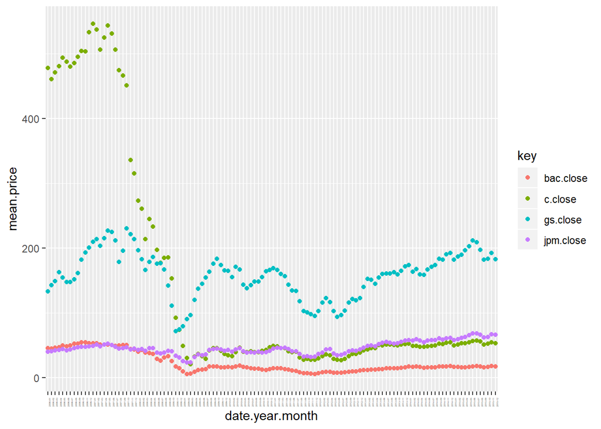

```r
plot.price <- banks.tidy.df %>%
  filter(grepl('close', key) ) %>%
   group_by(key,date.year.month) %>%
     summarize(mean.price= mean(as.double(value)))  %>%
       ggplot(aes(x=date.year.month, y=mean.price, colour=key)) +
  theme(axis.text.x = element_text(angle = 90, size = 2)) +
  geom_point()

plot.volume <- banks.tidy.df %>%
  filter(grepl('volume', key) ) %>%
   group_by(key,date.year.month) %>%
     summarize(mean.volume= mean(as.double(value)))  %>%
       ggplot(aes(x=date.year.month, y=log(mean.volume), colour=key)) +
  theme(axis.text.x = element_text(angle = 90, size = 2)) +
  geom_point()

plot.price
```

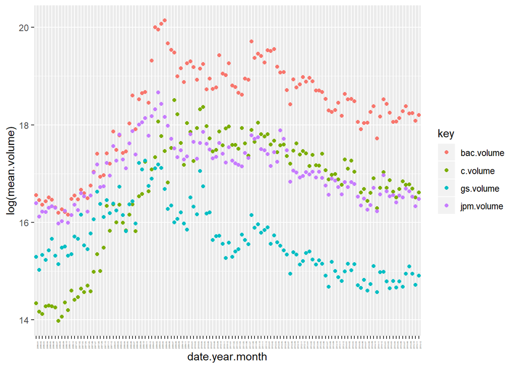

```r
plot.volume
```

*Based on the above point chart we can see how the stock prices for banks have been impacted during recession.*

#### **Analysis 2**

Comparing for Citi and JP Morgan; Getting the mean of the prices for the year 2008; the peak of the recession:

```r
data.citi.2008 <- banks.tidy.df %>%
  filter(grepl('c.close', key) , grepl('2008', date.year.month)) %>%
   separate(date.year.month,  c("date.year", "date.month"))

data.jpm.2008 <- banks.tidy.df %>%
  filter(grepl('jpm.close', key) , grepl('2008', date.year.month)) %>%
   separate(date.year.month,  c("date.year", "date.month"))

#52 week data for Citi for 2008
summary(as.double(data.citi.2008$value))
```

```
##    Min. 1st Qu.  Median    Mean 3rd Qu.    Max.
##   11.25   32.91   44.59  110.62  196.97  296.90
```

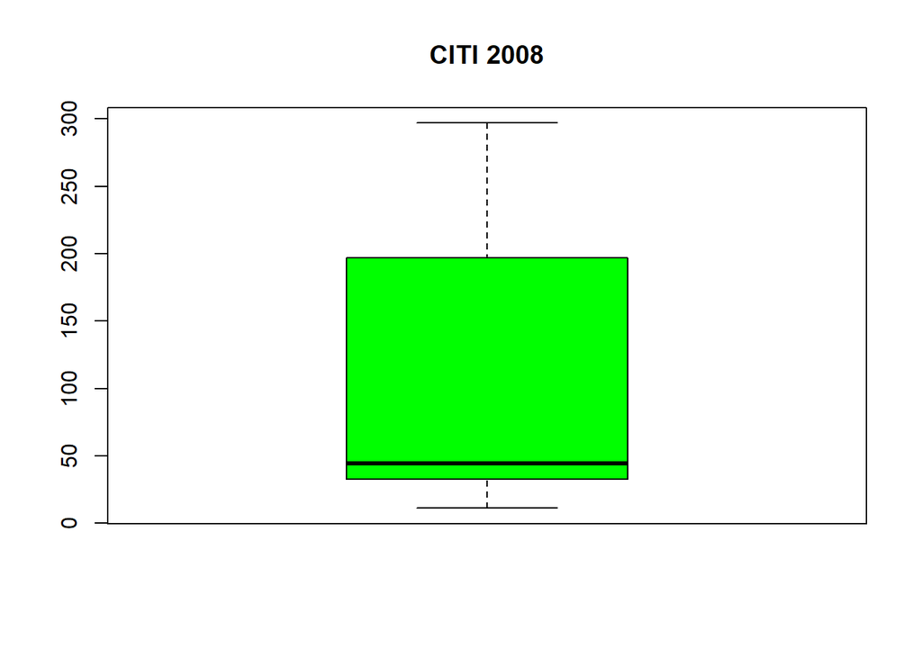

```r
boxplot(as.double(data.citi.2008$value), main="CITI 2008", col = "green")
```

```r
#52 week data for JPM for 2008
summary(as.double(data.jpm.2008$value))
```

```
##    Min. 1st Qu.  Median    Mean 3rd Qu.    Max.
##   22.72   37.00   40.49   39.83   43.46   49.85
```

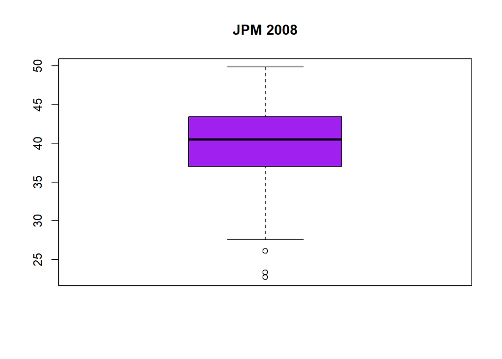

```r
boxplot(as.double(data.jpm.2008$value), main="JPM 2008", col = "purple")
```

*Based on the above box plot shapes we can say that Citi had a much bigger or higher price dip then JPM.*

## UNICEF

Reading the CSV file from GIT repository and loading into dataframe:

```r
theUrl <- "https://raw.githubusercontent.com/kamathvk1982/Data607-MajorAssignment-Project2/master/unicef-u5mr.csv"
unicef.full.df <- read.csv(file = theUrl, header = T , sep = ',', na.strings=c("NA","NaN", "") )
dim((unicef.full.df))
```

```
## [1] 196  67
```

Data Transformation and Tidy using dplyr and tidyr:

```r
# Next, we will tidy the data by reshaping the data layput in the table by using tidyr->gather function:
unicef.tidy.df <- gather(unicef.full.df, key = "Year", value = "Value", -CountryName)
unicef.tidy.df$Value  <- as.numeric(as.character(unicef.tidy.df$Value))
unicef.tidy.df$CountryName  <- str_trim(as.character(unicef.tidy.df$CountryName))

# Use the tidyr->drop_na function to drop the row on column Status having NA value:
unicef.tidy.df <- drop_na(unicef.tidy.df, Value)

# Use the sub  function to drop the 'U5MR.' from new column Year:
unicef.tidy.df$Year  <- sub('U5MR.','',unicef.tidy.df$Year)

kable(head(unicef.tidy.df))
```

|  | CountryName | Year | Value |
| --- | --- | --- | --- |
| 9 | Australia | 1950 | 31.6 |
| 31 | Canada | 1950 | 48.7 |
| 48 | Benin | 1950 | 348.2 |
| 49 | Denmark | 1950 | 34.1 |
| 51 | Dominican Republic | 1950 | 156.0 |
| 58 | Fiji | 1950 | 135.7 |

#### **Analysis 1**

Comparing a Developed Nation **United States of America** , a Developing nation **India** and a Under Developed Nation **Chad**:

```r
unicef.set1.df <-  unicef.tidy.df %>%
  filter(grepl('United States of America|India|Chad' , CountryName  )) %>%
  arrange(Year, CountryName)

kable(head(unicef.set1.df))
```

| CountryName | Year | Value |
| --- | --- | --- |
| United States of America | 1950 | 37.7 |
| United States of America | 1951 | 36.6 |
| United States of America | 1952 | 35.6 |
| India | 1953 | 279.5 |
| United States of America | 1953 | 34.7 |
| India | 1954 | 274.5 |

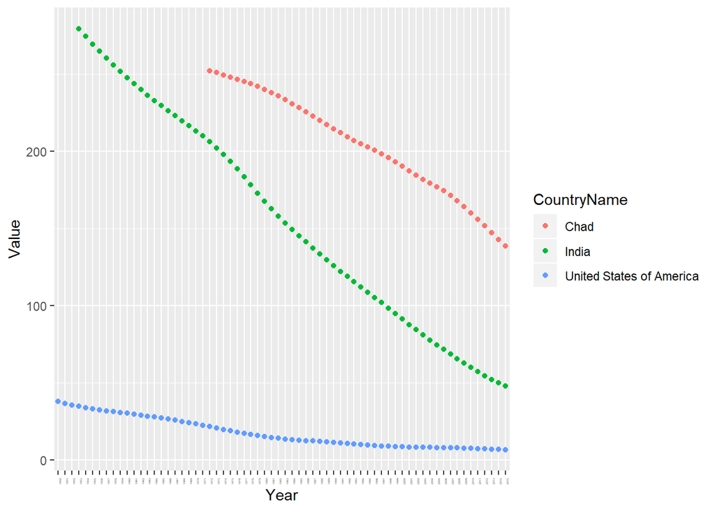

```r
unicef.set1.df %>%
       ggplot(aes(x=Year, y=Value, colour=CountryName)) +
  theme(axis.text.x = element_text(angle = 90, size = 2)) +
  geom_point()
```

*Based on the above Chart, we can see that the under 5 mortality is coming down for all three countries; but comparatively the counts are still high for Under Developed Countries and for Developing Countries .*

#### **Analysis 2**

List of countries where the under 5 mortality as of 2015 is still greater then 85:

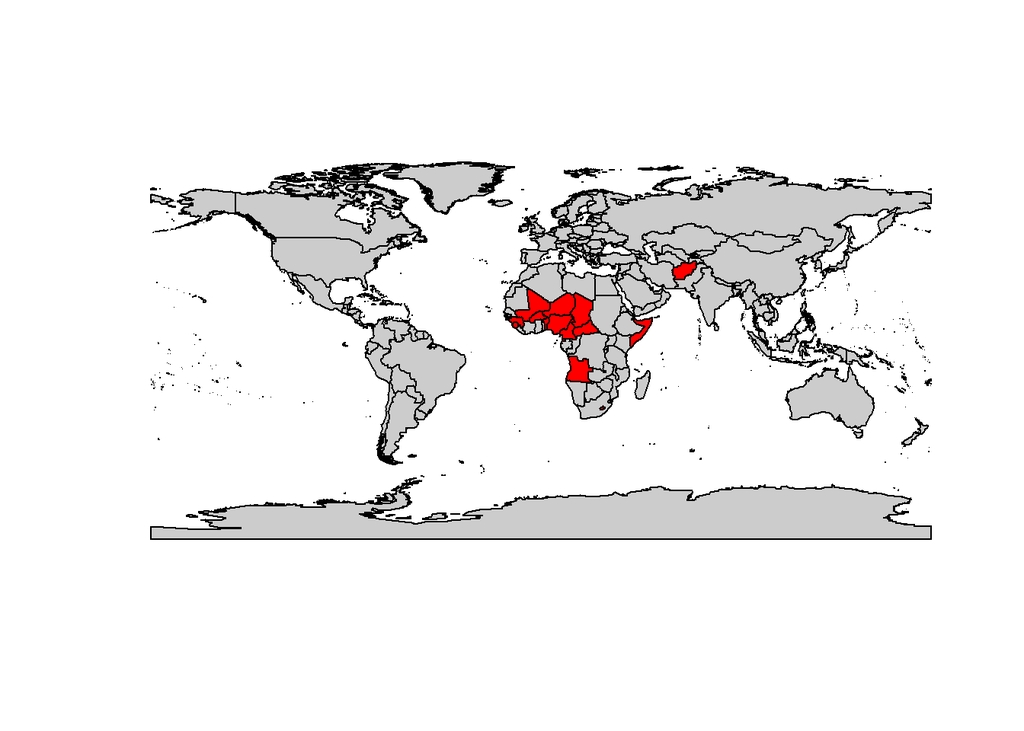

```r
# Filtering for 2015 and greater then 85:
unicef.set2.df <-  unicef.tidy.df %>%
  filter( Year=='2015' ,  Value > 85 ) %>%
  arrange( desc(Value))


# Ploting on world map:
data(wrld_simpl)
myCountries = wrld_simpl@data$NAME %in% names(table(unicef.set2.df$CountryName))
plot(wrld_simpl, col = c(gray(.80), "red")[myCountries+1])
```

*Based on the above World Map plotting we can see that most of these countries are in Continent Africa.*

## Hospital Consumer Assessment

Reading the CSV file from GIT repository and loading into dataframe:

```r
theUrl <- "https://raw.githubusercontent.com/kamathvk1982/Data607-MajorAssignment-Project2/master/HCAHPS.csv"
hcahps.full.df <- read.csv(file = theUrl, header = T , sep = ',', na.strings=c("NA","NaN", "Not Available") )

hcahps.full.df$HCAHPS.Answer.Percent  <- as.numeric(as.character(hcahps.full.df$HCAHPS.Answer.Percent))

kable(head(hcahps.full.df))
```

| State | HCAHPS.Question | HCAHPS.Measure.ID | HCAHPS.Answer.Description | HCAHPS.Answer.Percent | Footnote | Start.Date | End.Date |
| --- | --- | --- | --- | --- | --- | --- | --- |
| AK | Patients who reported that their nurses “Always” communicated well | H_COMP_1_A_P | Nurses “always” communicated well | 79 | NA | 04/01/2018 | 03/31/2019 |
| AK | Patients who reported that their nurses “Sometimes” or “Never” communicated well | H_COMP_1_SN_P | Nurses “sometimes” or “never” communicated well | 4 | NA | 04/01/2018 | 03/31/2019 |
| AK | Patients who reported that their nurses “Usually” communicated well | H_COMP_1_U_P | Nurses “usually” communicated well | 17 | NA | 04/01/2018 | 03/31/2019 |
| AK | Patients who reported that their nurses “Always” treated them with courtesy and respect | H_NURSE_RESPECT_A_P | Nurses “always” treated them with courtesy and respect | 86 | NA | 04/01/2018 | 03/31/2019 |
| AK | Patients who reported that their nurses “Sometimes” or “Never” treated them with courtesy and respect | H_NURSE_RESPECT_SN_P | Nurses “sometimes” or “never” treated them with courtesy and respect | 2 | NA | 04/01/2018 | 03/31/2019 |
| AK | Patients who reported that their nurses “Usually” treated them with courtesy and respect | H_NURSE_RESPECT_U_P | Nurses “usually” treated them with courtesy and respect | 12 | NA | 04/01/2018 | 03/31/2019 |

#### **Analysis 1**

Measure RESPECT (treated patients with courtesy and respect) for Nurses and Doctors for NJ and near by States:

```r
# we will create the required dataset using select, filter and separate function for data transformation:
respect.df <-  hcahps.full.df %>%
  select(c(State, Measure.ID = HCAHPS.Measure.ID,Answer.Percent=HCAHPS.Answer.Percent )) %>%
  filter(grepl('CT|NY|PA|NJ' , State    ) ,  grepl('RESPECT' , Measure.ID   ) ) %>%
  separate(Measure.ID,  c("Type", "Response"), sep = '_RESPECT_')


# Next, we will tidy the data by reshaping the data layput in the table by using tidyr->spread function:
respect.tidy.df <- spread(respect.df, key = Response, value = Answer.Percent  )
colnames(respect.tidy.df) <- c("State", "Type", "Always", "Sometimes.or.Never", "Usually")

kable(respect.tidy.df)
```

| State | Type | Always | Sometimes.or.Never | Usually |
| --- | --- | --- | --- | --- |
| CT | H_DOCTOR | 84 | 3 | 13 |
| CT | H_NURSE | 85 | 4 | 11 |
| NJ | H_DOCTOR | 83 | 4 | 13 |
| NJ | H_NURSE | 84 | 4 | 12 |
| NY | H_DOCTOR | 84 | 4 | 12 |
| NY | H_NURSE | 84 | 4 | 12 |
| PA | H_DOCTOR | 87 | 3 | 10 |
| PA | H_NURSE | 88 | 2 | 10 |

```r
respect.tidy.df %>% group_by(State, Type) %>% summarise (Positive.Ind = sum(as.integer(Always)+as.integer(Usually)))
```

| State | Type | Positive.Ind |
| --- | --- | --- |
| CT | H_DOCTOR | 97 |
| CT | H_NURSE | 96 |
| NJ | H_DOCTOR | 96 |
| NJ | H_NURSE | 96 |
| NY | H_DOCTOR | 96 |
| NY | H_NURSE | 96 |
| PA | H_DOCTOR | 97 |
| PA | H_NURSE | 98 |

*If we treat “Usually” and “Always” as a positive indicator then we can say that in State of CT the Doctors did better and in the State of PA the Nurses did better; for NJ and NY state the Doctors and Nurses were voted equally.*

#### **Analysis 2**

Measure RATING (a rating of 9 or 10 on a scale from 0 (lowest) to 10 (highest)) for HOSPITALS for NJ and near by States:

```r
# we will create the required dataset using select, filter and separate function for data transformation:
rating.df <-  hcahps.full.df %>%
  select(c(State, Measure.ID = HCAHPS.Measure.ID,Answer.Percent=HCAHPS.Answer.Percent )) %>%
  filter(grepl('CT|NY|PA|NJ' , State    ) ,  grepl('RATING' , Measure.ID    ) ) %>%
  separate(Measure.ID,  c("Type", "Response"), sep = '_RATING_')

# Next, we will tidy the data by reshaping the data layput in the table by using tidyr->spread function:
rating.tidy.df <- spread(rating.df, key = Response, value = Answer.Percent  )
colnames(rating.tidy.df) <- c("State", "Type", "low.6.or.Lower", "medium.7.or.8", "high.9.or.10")

kable(rating.tidy.df)
```

| State | Type | low.6.or.Lower | medium.7.or.8 | high.9.or.10 |
| --- | --- | --- | --- | --- |
| CT | H_HSP | 10 | 20 | 70 |
| NJ | H_HSP | 11 | 23 | 66 |
| NY | H_HSP | 10 | 24 | 66 |
| PA | H_HSP | 8 | 20 | 72 |

```r
rating.tidy.df %>% group_by(State, Type) %>% summarise (Positive.Ind = sum(as.integer(medium.7.or.8)+as.integer(high.9.or.10)))
```

| State | Type | Positive.Ind |
| --- | --- | --- |
| CT | H_HSP | 90 |
| NJ | H_HSP | 89 |
| NY | H_HSP | 90 |
| PA | H_HSP | 92 |

*If we treat “rating of 7 or 8 [medium]” and “rating of 9 or 10 [high]” as a positive indicator then we can say that in State of PA the Hospitals did better then other states.*

#### **Analysis 3**

Measure Doctors and Nurses across applicable questions in all States:

```r
# we will create the required dataset using select, filter and separate function for data transformation.
# BY looking at the data values we can say that in column Measure.ID any pattern of DOCTOR or COMP_2 can be treated as DOCTOR data
# and any pattern of NURSE or COMP_1 can be treated as NURSE data:

compare.doctor.df <-  hcahps.full.df %>%
  select(c(State, Measure.ID = HCAHPS.Measure.ID,Measure.ID2 = HCAHPS.Measure.ID, Answer.Percent=HCAHPS.Answer.Percent )) %>%
  filter(   grepl('DOCTOR|COMP_2' , Measure.ID  ), grepl('_A_P|_U_P' , Measure.ID2  ) )

compare.nurse.df <-  hcahps.full.df %>%
  select(c(State, Measure.ID = HCAHPS.Measure.ID,Measure.ID2 = HCAHPS.Measure.ID, Answer.Percent=HCAHPS.Answer.Percent )) %>%
  filter(   grepl('NURSE|COMP_1' , Measure.ID   ), grepl('_A_P|_U_P' , Measure.ID2  ) )
```

Next, we will calculate the sum of the scores:

```
## [1] "Total of Positive Response Score for Doctors is 19842"
```

```
## [1] "Total of Positive Response Score for Nurses is 19934"
```

*If we treat “Usually [_U_P]” and “Always [_A_P]” as a positive indicator then we can say that the Nurses had a better result then Doctors across all states*